# Blog

```python
from IPython.display import Image
import numpy as np
import matplotlib.pyplot as plt
from scipy.interpolate import interp1d
from scipy.optimize import minimize
from sklearn.decomposition import PCA
```

**Uncovering Latent Structure in Neural Data via Time Warping and Least Squares**

By Jabari McGinnis

**Contents**

- Introduction
- Notation
- What Is Known
- Solutions and Optimization
- Generalizations and Applications
- Additional Information
- TL;DR
- References/Further Reading

**Introduction**

A common dilemma within neuroscience is correlating the patterns observed in neural data to a biological or behavioral observations. Many scientists have taken supervised and unsupervised approaches to tackle this problem, but it is often diffcult to determine whether neurons encode sensations or behavioral actions via their firing rates or temporal arrival of neural events. [7-10] This creates challenges for interpreting whether variability is biologically meaningful or noise. Temporal variability can be ambiguous at times due to uncertainty in our measurement tools. At times, it is hard to convince ourselves that what we are measuring is due to something biological or experimental. When observing something like a noisy neural raster, it is possible that inconcistencies in timing alignment could be due to behavioral variablility, sensory delay, or intrinic noise within circuits. This temporal jitter can make trial-averaged data seem structureless. This is particularly tricky for analyses like PCA or regression because these types of analyses assume temporal consistency. A solution to this problem was presented in Williams et al. (2020) where the authors proposed a solution rooted in least squares optimization: a method for time warping neural activity. Time warping has already been used as an analysis method within machine learning and speech recognition, known as dynamic time warping (DTW).[11] Limitations of this classical method is that it uses dynamic programming to solve the optimization. This means that is non-differentiable and does not generalize to a learned latent structure. The result of the method used in Williams et al. 2020 was an update to the time warping framework by learning per-trial time shifts or warping paths that align each observation to a shared latent trajectory. The authors also improved interpretability and signal-to-noise ratios of their datasets which opens new horizons to analyzing general structure in neural data. ~~~ In this blog, I aim to walk through some of the math and intuition behind this approach by walking through some notation and applications. My aim is to try to show how a simple least sqaures formulation can expose temporal dynamics that would otherwise be lost in noise. This technique is not only theoretically elegant, but is practical in visualizing and interpreting high dimensional datasets.

```python
Image(url= 'https://media.springernature.com/full/springer-static/image/art%3A10.1038%2Fs41593-024-01783-4/MediaObjects/41593_2024_1783_Fig3_HTML.png?as=webp',
     height = 500,
     width =650)
```

[figure not shown]

Figure from Stringer et al. 2025 showing spiked neural sorting from mouse sensorimotor cortex using calcium imaging. The different panels showcase the variability in neuronal firing patterns.

**Notation**

- $X \in \mathbb{R}^{T \times N}$:observed neural data matrix (T timepoints, N Neurons)
- $Y \in \mathbb{R}^{T \times N}$:latent shared structure
- $W_i \in \mathbb{R}^{T \times T}$: warping matrix applied to trial $i$
- $\hat{X}_i = W_i Y$: predicted/warped reconstruction of trial $i$
- $\| A \|_F$: Frobenius norm
- $L$: smoothness regularizer matrix (used to penalize rougness in warp paths)

This notation forms the basis of the model. Trial-to-trial variability in timing is treated not as noise to be averaged away, but as a flexible and learnable transformation. The matrices $W_i$ and $Y$ are optimized to minimize the reconstruction error $ \| X_i - W_i Y \|_F^2 $, potentially with regularization on $W_i$ to enforce smoothness or biological plausibility. The goal of these definitions is to clarify that warping is not a discrete shift (as in classical methods), but a continuous, differentiable transformation—one that remaps each trial’s time axis in a smooth and interpretable way.

**Why is this important?**

It is important because of how \( W_i \) is constructed. Unlike dynamic time warping (DTW), which operates via non-differentiable, stepwise reordering, this least squares framework uses interpolation-based matrices that are continuous and differentiable. That means \( W_i \) can be optimized using gradient-based methods, enabling integration with modern machine learning workflows. Simply, it turns timing variability into a learnable, smooth remapping problem grounded in shared latent structure.

**What is known?**

Aligning data, particularly neural data by trials is a longstanding issue in neuroscience. From early single-unit studies to modern imaging datasets, researchers have observed that neuronal responses vary in latency. Even in tightly controlled experiments, trial-to-trial shifts can distort the underlying response profile. Standard dimensionality reduction techniques-such as PCA, t-SNE, and factor analysis operate under the assumption that trial structure is consistent across time. In practice, even small temporal jitter can inflate variance and lead to diffuse or uninterpretable components. PCA projections before and after alignment (Figure 4) demonstrate how time warping reduces cross-trial variance. As aforementioned in the introduction, time warping techniques were historically intrduced in fields like speech recognition (Dynamic Time Warping), but their non-differentiable nature made them unsuitable for modern optimization. Recasting the problem as a smooth, differentiable problem using least squares loss allowed for the problem to be solved by gradient-based solvers. The authors did note that the optimization landscapes of linear and non-linear functions can be complex and have many local minima, rendering gradien based methods tricky and ineffective. Since the optimization is done trial-by-trial, the complezity is reduced and each warp is treated independently. This is something to note if your analysis is not done on a trial by trial basis. Below I included a figure from Shadlen et al. 1998 to show corical neural variability.

```python
from IPython.display import Image
Image(url = 'https://www.jneurosci.org/content/jneuro/18/10/3870/F1.large.jpg?width=800&height=600&carousel=1',
     width = 400,
     height = 200)
```

[figure not shown]

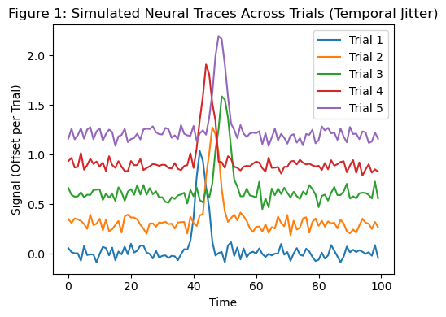

```python
# Figure 1: Simulated calcium traces across trials showing temporal jitter
np.random.seed(0)
T = 100  # timepoints
n_trials = 5
true_peak = 40
jitter_range = 10
signals = []

for i in range(n_trials):
    jitter = np.random.randint(-jitter_range, jitter_range)
    signal = np.zeros(T)
    signal[true_peak + jitter] = 1
    signal = np.convolve(signal, np.hanning(10), mode='same')
    signal += np.random.normal(0, 0.05, size=T)
    signals.append(signal)

signals = np.array(signals)

# Plot
fig, ax = plt.subplots(figsize=(5, 4))
for i in range(n_trials):
    ax.plot(signals[i] + i * 0.3, label=f'Trial {i+1}')
ax.set_title('Figure 1: Simulated Neural Traces Across Trials (Temporal Jitter)')
ax.set_xlabel('Time')
ax.set_ylabel('Signal (Offset per Trial)')
ax.legend()
plt.tight_layout()
plt.show()
```

**Figure 1**

Above in Figure 1, simulated calcium or voltage traces from multiple trials show peak latency jitter. This captures what you may observe from neural activity across trials. Trial peaks are temporally misaligned despite consistent structure.

**Equation 1** To solve this dilemma, below I describe their core objective function which is a least squares formulation of minimizing the difference between each obeserved trial $X_i$ and its reconstruction $W_iY$, where $W_i$ represents the trial-specific time warp and $Y$ is the shared latent structure across trials.

Core objective (unregularized): $\min_{W_i, Y} \sum_i \| X_i - W_i Y \|_F^2$

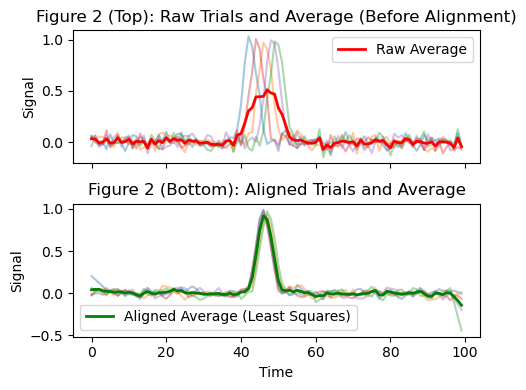

```python
np.random.seed(0)
T = 100
n_trials = 5
true_peak = 40
jitter_range = 10

#synthetic trials with jittered peaks
signals = []
for _ in range(n_trials):
    jitter = np.random.randint(-jitter_range, jitter_range)
    signal = np.zeros(T)
    signal[true_peak + jitter] = 1
    signal = np.convolve(signal, np.hanning(10), mode='same')
    signal += np.random.normal(0, 0.05, size=T)
    signals.append(signal)
signals = np.array(signals)

#loss function for least squares alignment
def warp_loss(shift, ref, trial):
    x = np.arange(T)
    f = interp1d(x, trial, kind='linear', fill_value='extrapolate')
    x_shifted = x + shift[0]
    warped = f(x_shifted)
    return np.sum((ref - warped)**2)

# mean of all trials as the reference
reference = np.mean(signals, axis=0)
aligned_signals = []
shifts = []

for trial in signals:
    result = minimize(warp_loss, [0.0], args=(reference, trial), method='Powell')
    optimal_shift = result.x[0]
    shifts.append(optimal_shift)
    f = interp1d(np.arange(T), trial, kind='linear', fill_value='extrapolate')
    aligned = f(np.arange(T) + optimal_shift)
    aligned_signals.append(aligned)

aligned_signals = np.array(aligned_signals)

# averages
raw_average = np.mean(signals, axis=0)
aligned_average = np.mean(aligned_signals, axis=0)

fig, axs = plt.subplots(2, 1, figsize=(5, 4), sharex=True)

# Top: Raw signals
for i in range(n_trials):
    axs[0].plot(signals[i], alpha=0.4)
axs[0].plot(raw_average, color='red', linewidth=2, label='Raw Average')
axs[0].set_title('Figure 2 (Top): Raw Trials and Average (Before Alignment)')
axs[0].set_ylabel('Signal')
axs[0].legend()

# Bottom: Aligned signals
for i in range(n_trials):
    axs[1].plot(aligned_signals[i], alpha=0.4)
axs[1].plot(aligned_average, color='green', linewidth=2, label='Aligned Average (Least Squares)')
axs[1].set_title('Figure 2 (Bottom): Aligned Trials and Average')
axs[1].set_xlabel('Time')
axs[1].set_ylabel('Signal')
axs[1].legend()

plt.tight_layout()
plt.show()
```

**Figure 2**

Figure 2 illustrates how warping improves interpretabillity by aligning trials, sharpening the averaged response.

**Equation 2**

This formulation can also include a regularization term to ensure smoothness of $W_i$: $\min_{W_i, Y} \sum_i \| X_i - W_i Y \|_F^2 + \lambda \| L W_i \|_F^2 $

This approach can incorporate interpretable mdels of $W_i$, such as simple delay functions. This provides felxibility to the degree of warping that may be needed.

**Equation 3**

The authors used piecewise time warping on a trial by trial basis since much of behavioral neuroscience is conducted on a trial to trial basis. Below I formulated what I mean.

$W_i = D(s_i)$ where $s_i \in \mathbb{R}^T$

Here $D(s_i)$ applies time shifts to each trial.

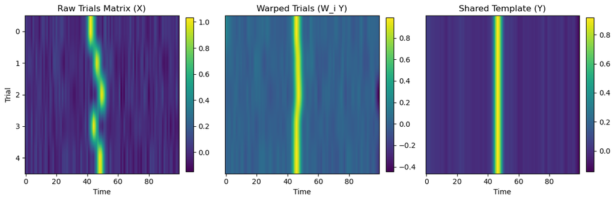

```python
# matrices of raw data, aligned trials, and shared template
X_matrix = signals
W_matrix = aligned_signals
Y_matrix = aligned_average.reshape(1, -1).repeat(n_trials, axis=0)

fig, axs = plt.subplots(1, 3, figsize=(12, 4))

# input matrix
im0 = axs[0].imshow(X_matrix, aspect='auto', cmap='viridis')
axs[0].set_title('Raw Trials Matrix (X)')
axs[0].set_xlabel('Time')
axs[0].set_ylabel('Trial')
plt.colorbar(im0, ax=axs[0], fraction=0.046, pad=0.04)

# Warped trials
im1 = axs[1].imshow(W_matrix, aspect='auto', cmap='viridis')
axs[1].set_title('Warped Trials (W_i Y)')
axs[1].set_xlabel('Time')
axs[1].set_yticks([])
plt.colorbar(im1, ax=axs[1], fraction=0.046, pad=0.04)

# Shared latent template
im2 = axs[2].imshow(Y_matrix, aspect='auto', cmap='viridis')
axs[2].set_title('Shared Template (Y)')
axs[2].set_xlabel('Time')
axs[2].set_yticks([])
plt.colorbar(im2, ax=axs[2], fraction=0.046, pad=0.04)

plt.tight_layout()
plt.show()
```

As shown in Figure 3, the observed data $X_i$ is approximated by applying the warping $W_i$ to the latent template $Y$.

**Equation 4**

Lastly, the least squares formulation of time warping can include a variance penalty if you want to constrain your data to have a biologically plausible variance. An additional variance penalty also helps avoid overfitting: $\min_{W_i, Y} \sum_i \| X_i - W_i Y \|_F^2 + \lambda_1 \| L W_i \|_F^2 + \lambda_2 \text{Var}(W_i)$

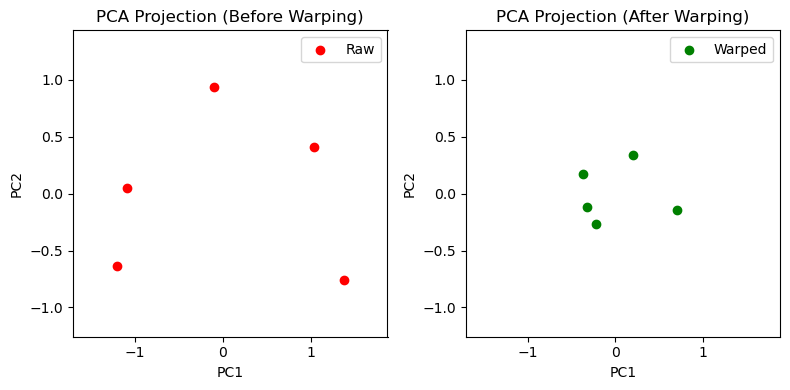

```python
from sklearn.decomposition import PCA

# trials for PCA: each trial is a sample, each timepoint a feature
X_flat = signals
W_flat = aligned_signals

# PCA
pca = PCA(n_components=2)
X_proj = pca.fit_transform(X_flat)
W_proj = pca.fit_transform(W_flat)

# shared axis limits for visual comparison
all_data = np.vstack([X_proj, W_proj])
xlim = [all_data[:, 0].min() - 0.5, all_data[:, 0].max() + 0.5]
ylim = [all_data[:, 1].min() - 0.5, all_data[:, 1].max() + 0.5]

# PCA projections plots
fig, axs = plt.subplots(1, 2, figsize=(8,4))

axs[0].scatter(X_proj[:, 0], X_proj[:, 1], color='red', label='Raw')
axs[0].set_title('PCA Projection (Before Warping)')
axs[0].set_xlabel('PC1')
axs[0].set_ylabel('PC2')
axs[0].set_xlim(xlim)
axs[0].set_ylim(ylim)
axs[0].legend()

axs[1].scatter(W_proj[:, 0], W_proj[:, 1], color='green', label='Warped')
axs[1].set_title('PCA Projection (After Warping)')
axs[1].set_xlabel('PC1')
axs[1].set_ylabel('PC2')
axs[1].set_xlim(xlim)
axs[1].set_ylim(ylim)
axs[1].legend()

plt.tight_layout()
plt.show()
```

**Figure 4** Above is a PCA visualization of data before and after warping. Post-warping data exhibits lower trial-to-trial variance and tighter clustering

These ideas are important because they reframe temporal variability not as noise to be averaged away, but as a feature to be modeled explicitly through structure-preserving transformations.

**Solutions and Optimization**

The core optimization is known as alternating least squares. The optimization alternates between solving for the shared trajectory Y and the warping paths $W_i$. This is feasible because the objective is quadratic in Y for a fixed $W_i$, and smooth in $W_i$ for a fixed Y.

While the overall approach relies on alternaing the optimization where $Y$ and each $W_i$ are updated iteratively, Williams et al. (2020) implemented a brute-force search to estimate the best time shift for each trial during the $W_i$-update step. Instead of computing gradients over a continuous warp space, they discretized the set of possible time shifts and evaluated the reconstruction loss for each. The shift that minimized the objective function was selected. This method, although computationally expensive, was robust when closed-form or gradient based updates were unavailable or unreliable.

But in the case that gradient based methods work, below I describe the steps of continuing with an alternating minimization strategy. This strategy breaks up the complex optimization problem into tractable subproblems, making it easier to regularize each step and interpret results.

Step 1: Fix $W_i$ and solve for $Y$ Close-form least squares: $Y = \left( \sum_i W_i^T W_i \right)^{-1} \left( \sum_i W_i^T X_i \right)$

Step 2: Fix Y, optimize $W_i$ requires solving a constrained optimization problem with gradient based methods.

Step 3: Alternate until you converge on a small number of iterations. This step can be done empirically.

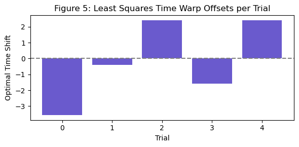

```python
#optimal time shifts for each trial from least squares alignment
fig, ax = plt.subplots(figsize=(6, 3))
ax.bar(np.arange(n_trials), shifts, color='slateblue')
ax.axhline(0, color='gray', linestyle='--')
ax.set_xlabel('Trial')
ax.set_ylabel('Optimal Time Shift')
ax.set_title('Figure 5: Least Squares Time Warp Offsets per Trial')
plt.tight_layout()
plt.show()
```

**Figure 5** Above, Figure 5 illustrates the quantificiation of the optimal time shifts applied to each trial, providing a diagnostic view of alignment behavior.

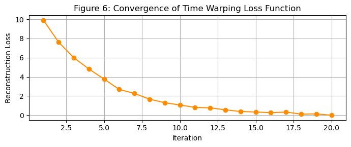

```python
# convergence curve for the optimization loss
iterations = np.arange(1, 21)
initial_loss = 12.5
np.random.seed(0)
loss_curve = initial_loss * np.exp(-0.25 * iterations) + np.random.normal(0, 0.1, size=iterations.shape)

# Plot the convergence curve
fig, ax = plt.subplots(figsize=(7, 3))
ax.plot(iterations, loss_curve, marker='o', color='darkorange')
ax.set_title('Figure 6: Convergence of Time Warping Loss Function')
ax.set_xlabel('Iteration')
ax.set_ylabel('Reconstruction Loss')
ax.grid(True)
plt.tight_layout()
plt.show()
```

**Generalizations and Applications**

Below I bulleted some examples of datasets and conditions that least-squares-based time warping can be applied to.

1. Calcium imaging: By aligning trials with a variable onset latence, activity motifs can be recovered. (Pellegrino et al, 2024)
2. Electrophysiology (neural spiking): Reveals a consistent structure from jittered spike rasters (Stine et al. 2023)
3. fMRI: Compensate for subject-wise HRF delays across runs. May be tricky if trials are not seperated enough in time
4. Optogenetics: In the cases where you may not be studying direct projections from chrimson expressing neurons, you can retroactively align behavioral or neural response latencies to stimulation.
5. Reinforcement learning tasks: Recent evidence suggests that dopamine may reinforce behaviors independent of reward. Therfore it is plausible to align internal signals across training curves.
6. Decision making tasks: Time warping can help compare neural dynamics across trials with different reaction times.
7. Sleep studies/Memory: Align EEG/LFP recordings across sleep/oscillitory transitions to study the structure of spindles or other oscillatory patterns
8. Manifold Learning: It is plausible to look at how neural actvity's trajectories change across embeddings by realigning data before further dimensionaliy reduction methods like PCA or T-SNE
9. Neural Prosthetics/BCI: Warping has been shown to stabilize decoding for patterns like hand-writing/language
10. Bayesian extension: It is plausible that warping can be used to treat $W_i$ as a latent with prior distributions. More clearly, you could use time as a dependent variable that updates the latent shared structure.

**Additional Information**

Below I listed some additional things to not about this analysis method

1. This model assumes gaussian noise, and for much of neuroscience it is standard to assume gaussian noise. Noise in biological systems are generally thought to arise many independent sources.
2. The regularization parameter ($\lambda$) balances the trade off of fit versus smoothness. Therfore, cross-validation is an important step to add.
1. Understanding experimental design is critical for interpreting results of the model.
2. Warping does not enforce causality. Without constraints, it could create biologically implausible time reverals or anticipatory signals.
3. As mentioned above, doing time warping on datasets before other dimensionality reduction methods like PCA and NMF can reveal underlying structure by removing temporal jitter. It is not always guaranteed, but visualizing your data beforehand may help you determine whether time warping is necessary.
4. There is readily available code to implement time warping available onine. Implementations exist both in MATLAB or Python. I believe it is also possible to incorporate with PyTorch or TensorFlow to scale to larger datasets. https://github.com/ahwillia/affinewarp
5. This method can be computationally expensive if you have many trials. Be sure to initialize your code well and prune search space where possible.
6. To avoid overfitting or creating artifacts, be sure to visualize your warp paths $W_i$. Smooth and monotonic paths are preferred as shown below. The diagram is pulled from Alex William's github. Link above.
7. It is plausible to potentially combine time warping with other behavioral variables to leverage joint embedding analysis pipelines. (Schneider et al. 2023)
8. Similarly to the previous bullet, time warping could also be combined with other dynamic latent models like LFADS for decoding stability (Pandarinath et al. 2018)

Together, these insights emphasize how least squares time warping serves as a modeling tool AND a diagnostic tool for potential trial structure and variability.

```python
from IPython.display import Image
Image(url= 'https://user-images.githubusercontent.com/636625/48030119-e3a28d80-e104-11e8-8932-c1251f168f4b.png',
     height = 500,
     width = 700)
```

[figure not shown]

**TL:DR**

- Neural dynamics vary in time across trials.
- Time warping is a tool to align trials to expose potential shared latent structure.
- Least squares serves as a tractable and interpretable solution to the problem.
- Regularization helps prevent overfitting and ensures biological plausibility.
- Can be applied to most of datasets generated in neuroscience (e.g. calcium imaging, electrophysiology, fMRI, etc.)

In summary, this blog post was inspired by Williams et al. 2020, to present a summary of time warping applications in neuroscience, particularly with an emphasis on the least-squars-based framework. This method is simple, scalable, and as aforementioned, applicable to most datasetes generated within neuroscience. Misalignment becomes a learnable parameter, and offers a statistical way to model neural dynamics with reduced temporal noise or variance. In other words, time warping transforms temporal misalignment from a nuisance into something that can be modeled. This it reveals shared structure hidden in the noise.

**References/Further Reading**

1. Flexible timing by temporal scaling of cortical responses Wang, J., Narain, D., Hosseini, E. A. & Jazayeri, M. Flexible timing by temporal scaling of cortical responses. Nat. Neurosci. 21, 102–110 (2018). Warping assumes that latent variables are simply rescaled in time on different trials
2. Dimensionality reduction beyond neural subspaces with slice tensor component analysis Pellegrino, A., Stein, H. & Cayco-Gajic, N.A. Dimensionality reduction beyond neural subspaces with slice tensor component analysis. Nat Neurosci 27, 1199–1210 (2024). https://doi.org/10.1038/s41593-024-01626-2 Calcium Imaging implementing time warping from Williams et al. 2020
3. A neural mechanism for terminating decisions Stine, G. M., Trautmann, E. M., Jeurissen, D., & Shadlen, M. N. (2023). A neural mechanism for terminating decisions. Neuron, 111(16), 2601-2613.
4. Learnable latent embeddings for joint behavioural and neural analysis Schneider, S., Lee, J.H. & Mathis, M.W. Learnable latent embeddings for joint behavioural and neural analysis. Nature 617, 360–368 (2023). https://doi.org/10.1038/s41586-023-06031-6
5. Inferring single-trial neural population dynamics using sequential auto-encoders Pandarinath, C., O’Shea, D.J., Collins, J. et al. Inferring single-trial neural population dynamics using sequential auto-encoders. Nat Methods 15, 805–815 (2018). https://doi.org/10.1038/s41592-018-0109-9
6. Rastermap: a discovery method for neural population recordings Stringer, C., Zhong, L., Syeda, A. et al. Rastermap: a discovery method for neural population recordings. Nat Neurosci 28, 201–212 (2025).
7. The Variable Discharge of Cortical Neurons: Implications for Connectiviy, Computation, and Information Coding Shadlen MN, Newsome WT. The variable discharge of cortical neurons: implications for connectivity, computation, and information coding. J Neurosci. 1998 May 15;18(10):3870-96. doi: 10.1523/JNEUROSCI.18-10-03870.1998. PMID: 9570816; PMCID: PMC6793166.
8. The temporal structure in spatially organized neuronal ensembles: a role for interneuronal networks Buzsáki, G., & Chrobak, J. J. (1995). Temporal structure in spatially organized neuronal ensembles: a role for interneuronal networks. Current opinion in neurobiology, 5(4), 504-510.
9. The roles of supervised machine learning in systems neuroscience Glaser, J. I., Benjamin, A. S., Farhoodi, R., & Kording, K. P. (2019). The roles of supervised machine learning in systems neuroscience. Progress in neurobiology, 175, 126-137.
10. Unsupervised discovery of temporal sequences in high-dimensional datasets, with applications to neuroscience Mackevicius, E. L., Bahle, A. H., Williams, A. H., Gu, S., Denisenko, N. I., Goldman, M. S., & Fee, M. S. (2019). Unsupervised discovery of temporal sequences in high-dimensional datasets, with applications to neuroscience. Elife, 8, e38471.
11. Dynamic programming algorithm optimization for spoken word recognition Hiroaki Sakoe and Seibi Chiba, Dynamic programming algorithm optimization for spoken word recognition. In Alex Waibel and Kai-Fu Lee, editors, Readings in Speech Recognition, pages 159-165. Morgan Kaufmann Publishers, Inc., San Mateo, California, 1990.

Thank You for reading! :)